# Metodos Estadistico - Clase 1

# Conceptos Basicos

1. **Poblacion**: Es el conjunto de todos los elementos que se desee analizar y que presentan una o varias caracteristicas en comun.
2. **Muestra**: Es el subconjunto representativo de elementos provinientes de una poblacion.
3. **Unidad Experimental**: Es cada uno de las personas, animales, cosas o identidades que conforman la poblacion de estudio.
4. **Variables** : Es toda caracteristica que se desea observar, medir o evaluar de las unidades experimentales.

Las variables pueden clasificarse en cuantitativas o cualitativas

1. **Variables Cualitativas**: Estas variables se dividen en:
1. **Nominales**: Son aquellas que definen un atributo de un elemento o unidad de estudio.
- Ejemplo: El color de pulpa del camote, puede ser morada, amarilla o naranja.
2. **Ordinales**: Son aquellas que expresan un atributo, y ademas, tambien pueden ser ordenadas.
- Ejemplo: Dosis de fertilizante, las cuales pueden ser baja, mediana y alta. Estos valores expresan una cualidad y su vez pueden ordenarse por la intensidad de la dosis.
2. **Variables Cuantitativas**: Son aquelals que expresan una cantidad. Estas se dividen en continuas y discretas.
1. Cuantitativas discretas: Son aquellas que tienen un numero finito o infinito numerable de valores posibles. Por lo general se obtienen mediante conteos.
- **Finito Numerable**: Tiene un rango finito
- **Ranfo Infinito Numerable**: Se caracterizan porque no tiene un maximo. Ejemplo, Numero de accidentes en un mes.
2. Cuantitativas continuas: Son aquellas que tienen un numero infinito no numerable de valores posibles. Por lo general se obtienen mediante instrumentos de medición.

## Conceptos relacionados a poblacion

- **Observacion** : Es el datos registrado producto de la medicion o apreciacion de una caracteristica en una unidad experimental.
- **Parametro** : ($\mu$, $\beta$, $\pi$, $\sigma$). Es una medida que resume los datos provinientes de la poblacion. Es decir es una funcion de todas las observaciones de una poblacion. *Ej.*: Luego de realizar un censo a las famlias del distrito de San Borja se obtuvo que el ingreso familiar promedio mensual es 8563.60 soles.
- **Estadistica, Estadistico o Estadigrafo** : Es una medida que resume los datos provinientes de la muestra. *Ej.*: Luego de realizar un muestreo a 30 familias del distrito de San Borja se obtuvo que el ingreso promedio familiar es 6452.30 soles.

## Estadistica Descriptiva

Son tecnicas de recolección, caracterización, resumen y presentación que permiten describir un conjunto de datos. Con un analisis descriptivo se pueden obtener indicadores (estimaciones puntuales), tablas de frecuencia (o contingencia) y graficos.

Para realizar un analisis descriptivo se debe tener en cuenta el tipo de variable (cuantitativo o cualitativo) y la cantidad de variables que se esta analizando (univarida, bivariada y multivariada).

### Analisis Descriptivo de Variables Categoricas

#### Tabla de Frecuencias

- Calculamos la tabla de frecuencia para la variable color de pulpa

```r
# Elaborar una tabla de frecuencia
tabla1 <- table(datos$colorPulpa)
tabla1
```

[output not shown]

Frecuencias porcentuales del color de pulpa

```r
#color de pulpa (cpula): 0 es rojo, 1 es morado, 2 es blanco
n<-sum(tabla1)
tabla1/n
```

[output not shown]

- Calculamos la tabla de frecuencia para la variable infectados

```r
#infectados: 0 is heathly and 1 is infected
# Elaborar una tabla de frecuencia
tabla2 <- table(datos$infectados)
tabla2
```

[output not shown]

Frecuencias porcentuales de los infectados

```r
n<-sum(tabla2)
tabla2/n
```

[output not shown]

#### Tabla de Contingencia

```r
tabla3 <- table(datos$colorPulpa, datos$infectados)
tabla3
```

[output not shown]

Para visualizar una tabla de contigencia podemos usar 2 tipos de graficos:

##### Grafico Circular

```r
pie(tabla3, col = c(1,3))
```

[output not shown]

##### Grafico de Barras

```r
barplot(tabla3)
```

[output not shown]

### Análisis Descriptivo de Variables Cuantitativas

#### Variables cuantitativas discretas

- Gráfico de Lineas

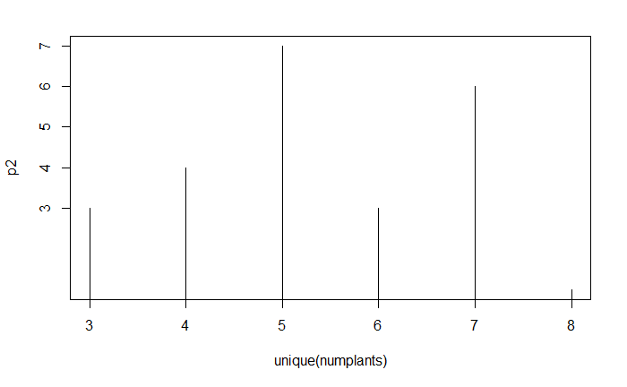

#### Variables cuantitativas continuas